# Exercise Sheet #3

Fortgeschrittene Statistische Software für NF

Minh Son Tran (12424799)  
2025-06-06

## Exercise 1

### d)

Git’s Strengths and Weaknesses:

2 strengths:

- It allow user to create branches, makes it easy to experiment without affecting the main codebase.
- It is open source and actively maintained.

2 weaknesses:

- User requires time to learn how to use Git properly because of confusing commands.
- Git is not very good for project with binary or very large files

## Exercise 2

### a)

GitHub repo: https://github.com/MinhSonTran97/exeRcise-sheet-3.git

## Exercise 3

### a)

```r
pixar_films <- read_csv("data/pixar_films.csv") %>%
  filter(!is.na(film))
```

The possible film_rating values are G, PG, N/A:

- “G”: General audiences
- “PG”: Parental guidance is advised
- “N/A”: Film Rating is not available / no rating provided. This is included since we only removed entries with missing titles.

```r
pixar_films <- pixar_films %>%
  mutate(film_rating = factor(film_rating, levels = c("G", "PG"), ordered = TRUE))
```

Converting film_rating into rating_factor is appropriate because:

- film_rating represents a set of discrete categories, not numeric values. These categories describe the type of audience the film is suitable for, not a measurable quantity.
- Treating film_rating as a factor helps R recognize it as a categorical variable, which allow us to better summarize, plot, and handle the data in modeling.

### b)

```r
pixar_films <- pixar_films %>%
  mutate(series = case_when(
    str_detect(film,"Toy Story") ~ "Toy Story",
    str_detect(film,"Cars") ~ "Cars",
    str_detect(film,"Incredibles") ~ "Incredibles",
    str_detect(film,"Finding") ~ "Finding",
    str_detect(film,"Monsters") ~ "Monsters",
    TRUE ~ NA_character_
  )) %>%
  group_by(series)

film_series <- pixar_films %>%
  filter(str_detect(film,"Toy Story|Cars|Incredibles|Finding|Monsters")) %>%
  summarise(films = paste(film, collapse = " - "), number_of_entries = n()) %>%
  ungroup()
film_series
```

```
# A tibble: 5 × 3
  series      films                                  number_of_entries
  <chr>       <chr>                                              <int>
1 Cars        Cars - Cars 2 - Cars 3                                 3
2 Finding     Finding Nemo - Finding Dory                            2
3 Incredibles The Incredibles - Incredibles 2                        2
4 Monsters    Monsters, Inc. - Monsters University                   2
5 Toy Story   Toy Story - Toy Story 2 - Toy Story 3…                 4
```

### c)

```r
public_response <- read_csv("data/public_response.csv")

unique(public_response$cinema_score)
```

```
[1] "A"  "A+" "A-" NA
```

We can see that the only rating scores are A, A+, A-, NA. We would assume that NA means the score is missing or not included, meaning the scoring system will look like this : A- < A < A+

```r
public_response <- public_response %>%
  mutate(cinema_score = factor(cinema_score, levels = c("A-", "A", "A+"), ordered = TRUE))

pixar_sum <- left_join(pixar_films, public_response, by = "film")
```

### d)

```r
pixar_series <- pixar_sum %>%
  filter(!is.na(series)) %>%
  filter(!is.na(metacritic))
```

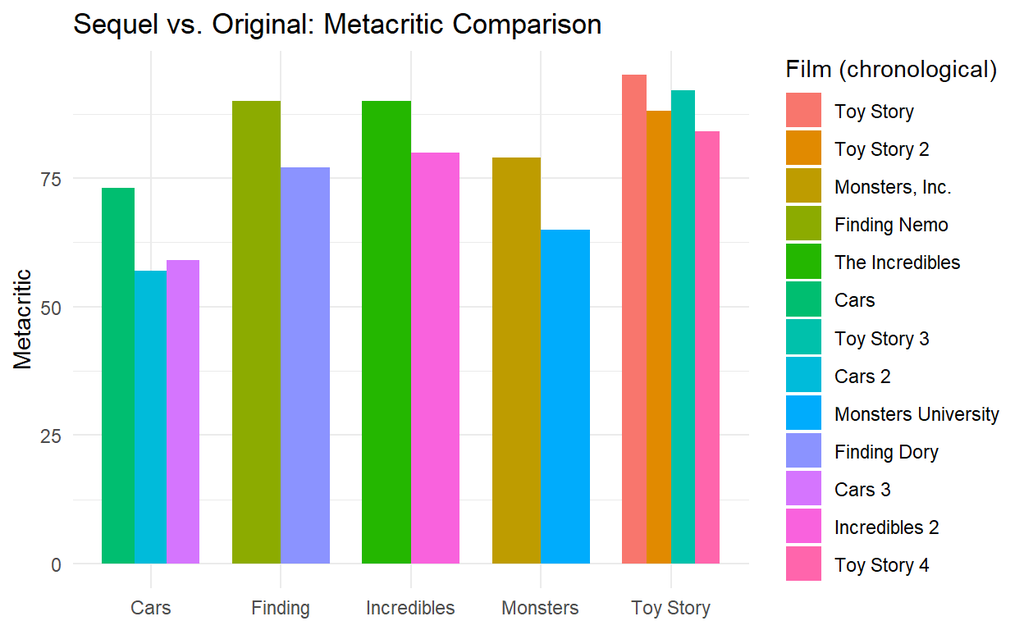

Figure 1: Performance comparison of sequels versus their first installments in film series

```r
ggplot(
  data = pixar_series,
  aes(
    x = series,
    y = metacritic,
    fill = fct_reorder(film, release_date)
  )) +
  geom_col(
    width = 0.75,
    position = position_dodge(width = 0.75)) +
  labs(
    x = NULL,
    y = "Metacritic",
    fill = "Film (chronological)",
    title = "Sequel vs. Original: Metacritic Comparison"
    ) +
  theme_minimal()
```

We can see in Figure 1 that the first installments in each series all have the highest Metacritic score. After that there, is a clear downward trend in most series, meaning that the sequels usually couldn’t perform as well as the prequels.

## Exercise 4

### c)

- Dataset Name: Cross-country literacy rates - World Bank, CIA World Factbook, and other sources
- Link: https://github.com/owid/owid-datasets/tree/master/datasets/Cross-country%20literacy%20rates%20-%20World%20Bank%2C%20CIA%20World%20Factbook%2C%20and%20other%20sources

### d)

Research question: How has the global literacy rate changed between 1970 and 2015?

The period from 1970 to 2015 includes major global education initiatives, such as UNESCO’s Education for All, making it an interesting and relevant timeframe to assess how these efforts have impacted the average literacy rate worldwide.

### e)

```r
world_literacy <- read_csv("data/Cross-country literacy rates - World Bank, CIA World Factbook, and other sources.csv")

literacy_trend <- world_literacy %>%
  filter(Year >= 1970) %>%
  group_by(Year) %>%
  summarise(avg_world_literacy = mean(`Literacy rates (World Bank, CIA World Factbook, and other sources)`), na.rm = TRUE)

literacy_change <- literacy_trend %>%
  filter(Year %in% c(1970, 2015)) %>%
  mutate(change = round(avg_world_literacy - lag(avg_world_literacy), 1)) %>%
  ungroup()
```

The global mean literacy rate rose from 76.03% in 1970 to 84.07% in 2015, an increase of about 8% over 45 years. While the increase may seem modest, it represents millions of additional literate people globally, which is a significant improvement, especially in regions starting with lower literacy.

### f)

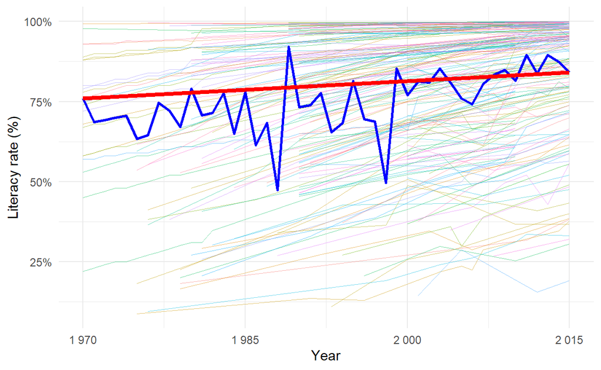

Figure 2: Global average and country-specific literacy rate trend, from 1970 to 2015.  
─── Global average literacy rate over time ─── Global average literacy rate differences between 1970 and 2015

```r
ggplot() +
  geom_line(
    data = world_literacy %>%
      filter(Year >= 1970),
    aes(
      x = Year,
      y = `Literacy rates (World Bank, CIA World Factbook, and other sources)`,
      group = Entity,
      color = Entity),
    alpha = 0.5,
    size = 0.25,
    show.legend = FALSE
    ) +
  geom_line(
    data = literacy_trend,
    aes(
      x = Year,
      y = avg_world_literacy
    ),
    color = "blue",
    size = 1
  ) +
  geom_line(
    data = literacy_change,
    aes(
      x = Year,
      y = avg_world_literacy
    ),
    color = "red",
    size = 1.5
  ) +
  scale_y_continuous(labels = scales::percent_format(scale = 1)) +
  scale_x_continuous(
    breaks = seq(1970, 2015, by = 15),
    labels = scales::label_number()) +
  labs(
    x = "Year",
    y = "Literacy rate (%)") +
  theme_minimal()
```